```r
options(OutDec = ".")  # Asegurar punto decimal en este chunk

# Establecer semilla aleatoria
set.seed(sample(1:10000, 1))

# Aleatorización del contexto del problema
# Contexto general del problema
contextos <- c(
  "grupo inicial", "muestra preliminar", "encuesta piloto", "estudio base",
  "investigación inicial", "censo preliminar", "sondeo inicial", "grupo control"
)
contexto <- sample(contextos, 1)

# Aleatorizar servicios o características
servicios <- c(
  "internet en su hogar", "computador propio", "teléfono inteligente",
  "acceso a agua potable", "seguro médico", "vehículo propio",
  "educación universitaria", "vivienda propia", "televisión por cable",
  "servicio de streaming", "energía solar"
)
servicio <- sample(servicios, 1)

# Aleatorizar términos para ampliar el grupo
terminos_ampliacion <- c(
  "aumentar", "incrementar", "expandir", "crecer", "extender", "ampliar"
)
termino_ampliacion <- sample(terminos_ampliacion, 1)

terminos_nuevos <- c(
  "nuevo grupo", "grupo ampliado", "grupo extendido", "muestra completa",
  "población final", "estudio completo", "grupo objetivo", "muestra definitiva"
)
termino_nuevo <- sample(terminos_nuevos, 1)

terminos_proposito <- c(
  "Para hacerlo", "Con este fin", "Para lograrlo", "Para ejecutar este plan",
  "Para realizar este procedimiento", "Como parte del proceso"
)
termino_proposito <- sample(terminos_proposito, 1)

# Aleatorizar verbos para la instrucción
verbos_instruccion <- c(
  "se proponen", "se establecen", "se definen", "se plantean",
  "se sugieren", "se especifican", "se indican"
)
verbo_instruccion <- sample(verbos_instruccion, 1)

# Aleatorizar términos para los pasos
terminos_pasos <- c(
  "pasos", "etapas", "procedimientos", "fases", "secuencias", "operaciones"
)
termino_pasos <- sample(terminos_pasos, 1)

# Parámetros numéricos
# Tamaño del grupo inicial (entre 100 y 500, múltiplo de 10)
grupo_inicial <- sample(seq(100, 500, by = 10), 1)

# Porcentaje inicial (entre 10% y 35%, múltiplo de 5%)
porcentaje_inicial <- sample(seq(10, 35, by = 5), 1)

# Porcentaje final (entre 40% y 70%, múltiplo de 5%)
porcentaje_final <- sample(seq(40, 70, by = 5), 1)

# Tamaño del grupo final (entre 1.5 y 3 veces el grupo inicial, múltiplo de 100)
factor_aumento <- sample(seq(1.5, 3, by = 0.5), 1)
grupo_final <- round(grupo_inicial * factor_aumento / 100) * 100

# Cálculos para la solución
valor_paso1 <- (porcentaje_inicial / 100) * grupo_inicial
valor_paso2 <- (porcentaje_final / 100) * grupo_final
valor_paso3 <- valor_paso2 - valor_paso1

# Verificación de coherencia matemática
# Asegurar que el número de personas nuevas con el servicio sea positivo
while (valor_paso3 <= 0) {
  porcentaje_final <- sample(seq(40, 70, by = 5), 1)
  valor_paso2 <- (porcentaje_final / 100) * grupo_final
  valor_paso3 <- valor_paso2 - valor_paso1
}

# Asegurar que el número de personas nuevas con el servicio sea un número entero
valor_paso1 <- round(valor_paso1)
valor_paso2 <- round(valor_paso2)
valor_paso3 <- round(valor_paso3)

# Generar alternativas de respuesta (distractores)
# Distractor 1: División en lugar de resta
distractor1 <- round(valor_paso2 / valor_paso1)

# Distractor 2: Usar porcentaje del grupo final para calcular grupo inicial
distractor2 <- round((porcentaje_final / 100) * grupo_inicial)

# Distractor 3: Restar porcentajes y aplicar al grupo final
distractor3 <- round(((porcentaje_final - porcentaje_inicial) / 100) * grupo_final)

# Distractor 4: Sumar en lugar de restar
distractor4 <- round(valor_paso1 + valor_paso2)

# Asegurar que los distractores sean diferentes entre sí y de la respuesta correcta
distractores <- c(distractor1, distractor2, distractor3, distractor4)
respuesta_correcta <- valor_paso3

# Si algún distractor es igual a la respuesta correcta, modificarlo ligeramente
for (i in 1:length(distractores)) {
  if (distractores[i] == respuesta_correcta) {
    distractores[i] <- distractores[i] + sample(c(-10, 10, -20, 20), 1)
  }
}

# Asegurar que los distractores son diferentes entre sí
for (i in 1:(length(distractores) - 1)) {
  for (j in (i+1):length(distractores)) {
    if (distractores[i] == distractores[j]) {
      distractores[j] <- distractores[j] + sample(c(-5, 5, -15, 15), 1)
    }
  }
}

# Seleccionar 3 distractores aleatorios de los 4 generados
distractores_seleccionados <- sample(distractores, 3)

# Crear opciones de respuesta y determinar la correcta
opciones <- c(respuesta_correcta, distractores_seleccionados)
opciones <- sort(opciones)  # Ordenar de menor a mayor para consistencia
indice_correcto <- which(opciones == respuesta_correcta)

# Vector de solución para r-exams
solucion <- rep(0, 4)
solucion[indice_correcto] <- 1
```

```r
# Código Python para generar un gráfico explicativo
codigo_python <- paste0("
import matplotlib.pyplot as plt
import numpy as np
import matplotlib
matplotlib.rcParams['font.size'] = 10

# Datos del problema
grupo_inicial = ", grupo_inicial, "
grupo_final = ", grupo_final, "
porcentaje_inicial = ", porcentaje_inicial, "
porcentaje_final = ", porcentaje_final, "
valor_paso1 = ", valor_paso1, "
valor_paso2 = ", valor_paso2, "
valor_paso3 = ", valor_paso3, "

# Aleatorizar colores para el gráfico
import random
colores = ['#3498db', '#e74c3c', '#2ecc71', '#f39c12', '#9b59b6', '#1abc9c']
random.shuffle(colores)

# Crear figura
fig, ax = plt.subplots(figsize=(6, 4))

# Configurar el ancho de las barras
ancho_barra = 0.35

# Posiciones de las barras en el eje x
x = np.array([0, 1])

# Barras para personas con el servicio
personas_con_servicio = [valor_paso1, valor_paso2]
barras1 = ax.bar(x - ancho_barra/2, personas_con_servicio, ancho_barra, color=colores[0],
                label=f'Con servicio ({porcentaje_inicial}% → {porcentaje_final}%)')

# Barras para personas sin el servicio
personas_sin_servicio = [grupo_inicial - valor_paso1, grupo_final - valor_paso2]
barras2 = ax.bar(x + ancho_barra/2, personas_sin_servicio, ancho_barra, color=colores[1],
                label=f'Sin servicio ({100-porcentaje_inicial}% → {100-porcentaje_final}%)')

# Barras para el total
ax.bar(x, [grupo_inicial, grupo_final], ancho_barra*2, alpha=0.1, color='gray',
      label=f'Total ({grupo_inicial} → {grupo_final})')

# Etiquetas en las barras
def agregar_etiquetas(barras):
    for barra in barras:
        altura = barra.get_height()
        ax.annotate(f'{int(altura)}',
                    xy=(barra.get_x() + barra.get_width() / 2, altura),
                    xytext=(0, 3),  # 3 puntos de desplazamiento vertical
                    textcoords='offset points',
                    ha='center', va='bottom')

agregar_etiquetas(barras1)
agregar_etiquetas(barras2)

# Etiquetas, título y leyenda
ax.set_ylabel('Número de personas')
ax.set_title('Distribución de la población antes y después')
ax.set_xticks(x)
ax.set_xticklabels(['Grupo inicial', 'Grupo final'])
ax.legend()

# Flecha indicando personas nuevas con servicio
ax.annotate('',
            xy=(1, valor_paso2/2), xycoords='data',
            xytext=(0, valor_paso1/2), textcoords='data',
            arrowprops=dict(arrowstyle='->', connectionstyle='arc3,rad=0.2', color=colores[2], lw=2))

ax.annotate(f'Diferencia: {valor_paso3}\\npersonas nuevas\\ncon el servicio',
            xy=(0.5, (valor_paso1 + valor_paso2)/4),
            ha='center', va='center',
            bbox=dict(boxstyle='round,pad=0.5', fc=colores[2], alpha=0.7))

plt.tight_layout()
plt.savefig('grafico_porcentajes.png', dpi=150, bbox_inches='tight')
plt.close()
")

# Ejecutar código Python para generar la figura
py_run_string(codigo_python)
```

```r
# Aleatorizar colores para la tabla
color_fila_titulo <- sample(c('#3498db', '#e74c3c', '#2ecc71', '#f39c12', '#9b59b6', '#1abc9c'), 1)
color_fila_par <- sample(c('#f5f5f5', '#e8f4f8', '#f0f9e8', '#fff5e6', '#f0e6fa', '#e5f9f5'), 1)
color_fila_impar <- "#ffffff"
color_borde <- sample(c('#34495e', '#7f8c8d', '#2c3e50', '#95a5a6'), 1)

# Generar tabla usando Python/Matplotlib
codigo_python_tabla <- paste0("
import matplotlib.pyplot as plt
import numpy as np
from matplotlib.table import Table

# Datos de la tabla
pasos = ['Paso 1', 'Paso 2', 'Paso 3']
procedimientos = [
    'Hallar el ", porcentaje_inicial, "% del número de personas del ", contexto, ".',
    'Hallar el ", porcentaje_final, "% del número de personas del ", termino_nuevo, " de ", grupo_final, " personas.',
    'Restar el valor obtenido en el paso 1 del valor obtenido en el paso 2.'
]

# Crear figura con dimensiones adecuadas
fig, ax = plt.subplots(figsize=(10, 3.5))

# Ocultar ejes
ax.axis('off')
ax.axis('tight')

# Crear tabla
tabla = ax.table(
    cellText=[[pasos[0], procedimientos[0]], [pasos[1], procedimientos[1]], [pasos[2], procedimientos[2]]],
    colLabels=['Paso', 'Procedimiento'],
    colWidths=[0.1, 0.9],  # Ancho relativo de las columnas
    loc='center',
    cellLoc='left'
)

# Configurar estilo de la tabla
tabla.auto_set_font_size(False)
tabla.set_fontsize(9)

# Altura de las filas
for key, cell in tabla.get_celld().items():
    cell.set_height(0.25)
    cell.set_text_props(va='center', ha='left', wrap=True)
    cell.set_edgecolor('", color_borde, "')

    # Estilo para el encabezado
    if key[0] == 0:
        cell.set_fontsize(10)
        cell.set_text_props(weight='bold', ha='center')
        cell.set_facecolor('", color_fila_titulo, "')
    # Estilo para filas alternas
    elif key[0] % 2 == 0:
        cell.set_facecolor('", color_fila_par, "')
    else:
        cell.set_facecolor('", color_fila_impar, "')

# Guardar la tabla como imagen en el directorio actual
import os
plt.tight_layout()
plt.savefig('tabla_pasos.png', dpi=150, bbox_inches='tight', transparent=True)
# También guardar en el directorio temporal que usa R-exams
plt.savefig(os.path.join(os.getcwd(), 'tabla_pasos.png'), dpi=150, bbox_inches='tight', transparent=True)
plt.close()
")

# Ejecutar código Python para generar la tabla
py_run_string(codigo_python_tabla)
```

```r
# Generar una imagen de contexto usando iconos para mostrar el problema
codigo_python_contexto <- paste0("
import matplotlib.pyplot as plt
import numpy as np
import matplotlib
matplotlib.rcParams['font.size'] = 10

# Datos del problema
grupo_inicial = ", grupo_inicial, "
grupo_final = ", grupo_final, "
porcentaje_inicial = ", porcentaje_inicial, "
porcentaje_final = ", porcentaje_final, "

# Crear figura
fig, ax = plt.subplots(figsize=(8, 3.5))
ax.axis('off')

# Coordenadas iniciales
y_inicial = 0.7
y_final = 0.3
x_centro = 0.5
ancho_grupo = 0.4

# Grupo inicial (círculo superior)
circle_inicial = plt.Circle((x_centro, y_inicial), 0.25, fill=True, alpha=0.2,
                           edgecolor='black', linewidth=1.5, zorder=1)
ax.add_patch(circle_inicial)

# Grupo final (círculo inferior)
circle_final = plt.Circle((x_centro, y_final), 0.4, fill=True, alpha=0.2,
                         edgecolor='black', linewidth=1.5, zorder=1)
ax.add_patch(circle_final)

# Flecha de transición
ax.arrow(x_centro, y_inicial-0.25, 0, -0.1, head_width=0.05,
        head_length=0.03, fc='black', ec='black', zorder=2)

# Textos en los círculos
ax.text(x_centro, y_inicial+0.02, f'Grupo inicial\\n{grupo_inicial} personas\\n{porcentaje_inicial}% con servicio',
       ha='center', va='center', fontweight='bold', fontsize=11)

ax.text(x_centro, y_final+0.02, f'Grupo final\\n{grupo_final} personas\\n{porcentaje_final}% con servicio',
       ha='center', va='center', fontweight='bold', fontsize=11)

# Definir área de personas con servicio en el grupo inicial (usando sombreado)
servicio_inicial = circle_inicial.get_radius() * (porcentaje_inicial/100)**0.5
circle_servicio_inicial = plt.Circle((x_centro, y_inicial), servicio_inicial,
                                   fill=True, color='#3498db', alpha=0.5,
                                   edgecolor='black', linewidth=1, zorder=2)
ax.add_patch(circle_servicio_inicial)

# Definir área de personas con servicio en el grupo final (usando sombreado)
servicio_final = circle_final.get_radius() * (porcentaje_final/100)**0.5
circle_servicio_final = plt.Circle((x_centro, y_final), servicio_final,
                                 fill=True, color='#3498db', alpha=0.5,
                                 edgecolor='black', linewidth=1, zorder=2)
ax.add_patch(circle_servicio_final)

# Añadir interrogante para la pregunta
ax.text(x_centro+0.5, y_final-0.05, '?',
       ha='center', va='center', fontweight='bold', fontsize=24,
       bbox=dict(boxstyle='circle', facecolor='#e74c3c', alpha=0.8, pad=0.5))

# Establecer límites
ax.set_xlim(0, 1)
ax.set_ylim(0, 1)
ax.set_aspect('equal')

plt.savefig('contexto_porcentajes.png', dpi=150, bbox_inches='tight', transparent=True)
plt.close()
")

# Ejecutar código Python para generar la imagen de contexto
py_run_string(codigo_python_contexto)
```

# Question

En un estudio base de 470 personas, el 25% de estas tiene vehículo propio. Se va a extender el estudio base hasta completar un grupo objetivo de 900 personas, de manera que, en este grupo objetivo, el porcentaje de personas que tengan vehículo propio en sus hogares sea del 40%.

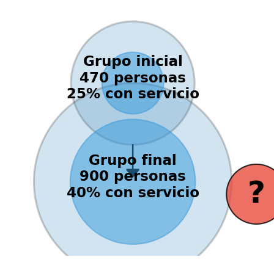

Es necesario saber cuántas de las personas que ingresan nuevas deben tener vehículo propio, y, Para lograrlo, se se proponen los siguientes operaciones:

| Paso | Procedimiento |
| --- | --- |
| 1 | Hallar el 25% del número de personas del estudio base. |
| 2 | Hallar el 40% del número de personas del grupo objetivo de 900 personas. |
| 3 | Restar el valor obtenido en el paso 1 del valor obtenido en el paso 2. |

¿Cuál es el valor obtenido en el último paso del procedimiento anterior?

## Answerlist

- 3
- 135
- 188
- 242

# Solution

La respuesta correcta es: **242**.

Para resolver este problema, seguimos los pasos indicados:

**Paso 1**: Hallar el 25% del número de personas del estudio base. $25\% \text{ de } 470 = \frac{25}{100} \times 470 = 118$

**Paso 2**: Hallar el 40% del número de personas del grupo objetivo de 900 personas. $40\% \text{ de } 900 = \frac{40}{100} \times 900 = 360$

**Paso 3**: Restar el valor obtenido en el paso 1 del valor obtenido en el paso 2. $360 - 118 = 242$

Por lo tanto, se necesitan 242 personas nuevas que tengan vehículo propio.

**Verificación**: - En el estudio base inicial, hay 118 personas con vehículo propio (25% de 470). - El número total de personas nuevas es 430. - De estas personas nuevas, 242 deben tener vehículo propio. - Al final, habrá 118 + 242 = 360 personas con vehículo propio (40% de 900).

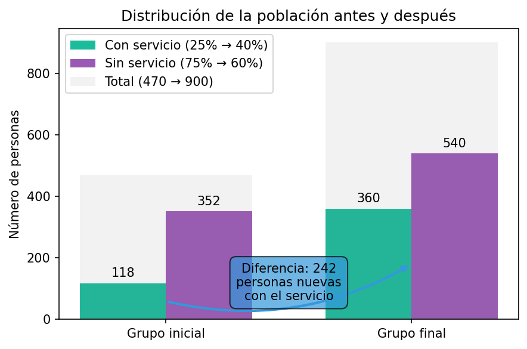

## Answerlist

- Falso
- Falso
- Falso
- Verdadero

# Meta-information

exname: porcentajes_grupos_poblacion extype: schoice exsolution: 0001 exshuffle: TRUE exsection: Porcentajes|Aplicaciones porcentuales